# PART A

### Part 2.1 b- Check percentage of missing values and impute with correct approach.

```python
print(vehicle_df.isnull().sum())
```

```
compactness                    0
circularity                    5
distance_circularity           4
radius_ratio                   6
pr.axis_aspect_ratio           2
max.length_aspect_ratio        0
scatter_ratio                  1
elongatedness                  1
pr.axis_rectangularity         3
max.length_rectangularity      0
scaled_variance                3
scaled_variance.1              2
scaled_radius_of_gyration      2
scaled_radius_of_gyration.1    4
skewness_about                 6
skewness_about.1               1
skewness_about.2               1
hollows_ratio                  0
class                          0
dtype: int64
```

```python
missing_values = ["n/a", "na", "--", " ","?","-",]
for feature in vehicle_df.columns:
    print(feature ,pd.unique(vehicle_df[feature]),"\n")
    if (not vehicle_df[vehicle_df[feature].isin(missing_values)].empty):
        print("Unexpected value found in",feature,"column in the indices ", vehicle_df[vehicle_df[feature].isin(missing_values)].index)
    else:
        print("No unexpected values")
    print("----------------------------------")

#Checking percentage of missing values in each column
percent_missing = vehicle_df.isnull().sum() * 100 / len(vehicle_df)
missing_value_df = pd.DataFrame({'percent_missing': percent_missing})
missing_value_df
```

```
compactness [ 95  91 104  93  85 107  97  90  86  88  89  94  96  99 101  84  87  83
 102  80 100  82 106  81 119  78  92  98 103  77  73  79 110 108 109 111
 105 112 116 113 117 115  76 114]

No unexpected values
----------------------------------
circularity [48. 41. 50. 44. nan 43. 34. 36. 46. 42. 49. 55. 54. 56. 47. 37. 39. 53.
 45. 38. 35. 40. 59. 52. 51. 58. 57. 33.]

No unexpected values
----------------------------------
distance_circularity [ 83.  84. 106.  82.  70.  73.  66.  62.  98.  74.  85.  79. 103.  51.
  77. 100.  75.  53.  64. 105.  80.  54.  63. 107.  nan  72.  86.  68.
 104.  87.  76.  81.  71. 101.  96.  78. 108.  91.  89.  94.  92.  60.
  57.  65.  50.  88. 109.  95.  90.  58.  69.  47.  40.  59. 110.  93.
 102. 112.  61.  42.  49.  44.  52.  55.]

No unexpected values
----------------------------------
radius_ratio [178. 141. 209. 159. 205. 172. 173. 157. 140.  nan 143. 136. 171. 144.
 203. 201. 109. 197. 186. 215. 153. 121. 148. 219. 154. 119. 193. 129.
 160. 151. 222. 177. 118. 306. 176. 169. 214. 105. 137. 183. 220. 145.
 133. 122. 147. 115. 174. 228. 175. 185. 195. 221. 212. 135. 120. 156.
 125. 164. 161. 227. 191. 111. 170. 113. 127. 188. 180. 116. 158. 162.
 211. 152. 124. 252. 150. 130. 198. 202. 199. 128. 142. 163. 155. 184.
 165. 322. 194. 218. 216. 223. 149. 131. 139. 179. 166. 187. 167. 231.
 168. 126. 206. 210. 110. 189. 134. 132. 230. 196. 208. 138. 200. 225.
 246. 207. 192. 117. 123. 146. 190. 182. 204. 224. 333. 213. 226. 238.
 181. 114. 104. 112. 234. 235. 250. 232. 217.]

No unexpected values
----------------------------------
pr.axis_aspect_ratio [ 72.  57.  66.  63. 103.  50.  65.  61.  62.  55.  68.  58.  71.  52.
  69.  nan  64.  59.  67. 126.  54.  73.  51.  70.  53.  56.  74.  60.
  76.  75.  49. 133.  47. 102. 138.  48.  97. 105.]

No unexpected values
----------------------------------
max.length_aspect_ratio [10  9 52  6  7 11  5  8 49 12 22 48  4 13  3 43 25 46 19  2 55]

```

[output cut: 114 more lines]

```
skewness_about.2 [187. 189. 188. 199. 180. 181. 200. 193. 195. 194. 196. 197. 186. 198.
 185. 179. 192. 191. 190. 183. 184. 202. 201. 182. 176. 178. 203. 177.
  nan 204. 206.]

No unexpected values
----------------------------------
hollows_ratio [197 199 196 207 183 204 202 208 195 194 185 193 192 206 201 205 200 189
 182 209 184 187 188 198 191 190 203 186 210 211 181]

No unexpected values
----------------------------------
class ['van' 'car' 'bus']

No unexpected values
----------------------------------
```

|  | percent_missing |
| --- | --- |
| compactness | 0.000000 |
| circularity | 0.591017 |
| distance_circularity | 0.472813 |
| radius_ratio | 0.709220 |
| pr.axis_aspect_ratio | 0.236407 |
| max.length_aspect_ratio | 0.000000 |
| scatter_ratio | 0.118203 |
| elongatedness | 0.118203 |
| pr.axis_rectangularity | 0.354610 |
| max.length_rectangularity | 0.000000 |
| scaled_variance | 0.354610 |
| scaled_variance.1 | 0.236407 |
| scaled_radius_of_gyration | 0.236407 |
| scaled_radius_of_gyration.1 | 0.472813 |
| skewness_about | 0.709220 |
| skewness_about.1 | 0.118203 |
| skewness_about.2 | 0.118203 |
| hollows_ratio | 0.000000 |
| class | 0.000000 |

```python
#replace missing variable('?') into null variable using numpy
vehicle_df = vehicle_df.replace(' ', np.nan)
```

```python
#imputing the median
for i in vehicle_df.columns[:17]:
    median_value = vehicle_df[i].median()
    vehicle_df[i] = vehicle_df[i].fillna(median_value)
```

```python
print(vehicle_df.isnull().sum())
```

```
compactness                    0
circularity                    0
distance_circularity           0
radius_ratio                   0
pr.axis_aspect_ratio           0
max.length_aspect_ratio        0
scatter_ratio                  0
elongatedness                  0
pr.axis_rectangularity         0
max.length_rectangularity      0
scaled_variance                0
scaled_variance.1              0
scaled_radius_of_gyration      0
scaled_radius_of_gyration.1    0
skewness_about                 0
skewness_about.1               0
skewness_about.2               0
hollows_ratio                  0
class                          0
dtype: int64
```

### Part 2.1 c- Visualize a Pie-chart and print percentage of values for variable ‘class’.

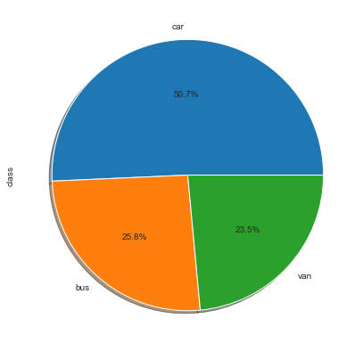

```python
fig = plt.figure(figsize =(10, 7))
vehicle_df['class'].value_counts().plot.pie(autopct='%1.1f%%',shadow=True,)
```

### Part 2.1 d - Check for duplicate rows in the data and impute with correct approach.

```python
vehicle_df.duplicated().sum()
```

```
0
```

# 2.2. Data Preparation:

### Part 2.2 a - Split data into X and Y.

```python
vehicle_df.head()
```

|  | compactness | circularity | distance_circularity | radius_ratio | pr.axis_aspect_ratio | max.length_aspect_ratio | scatter_ratio | elongatedness | pr.axis_rectangularity | max.length_rectangularity | scaled_variance | scaled_variance.1 | scaled_radius_of_gyration | scaled_radius_of_gyration.1 | skewness_about | skewness_about.1 | skewness_about.2 | hollows_ratio | class |
| --- | --- | --- | --- | --- | --- | --- | --- | --- | --- | --- | --- | --- | --- | --- | --- | --- | --- | --- | --- |
| 0 | 95 | 48.0 | 83.0 | 178.0 | 72.0 | 10 | 162.0 | 42.0 | 20.0 | 159 | 176.0 | 379.0 | 184.0 | 70.0 | 6.0 | 16.0 | 187.0 | 197 | van |
| 1 | 91 | 41.0 | 84.0 | 141.0 | 57.0 | 9 | 149.0 | 45.0 | 19.0 | 143 | 170.0 | 330.0 | 158.0 | 72.0 | 9.0 | 14.0 | 189.0 | 199 | van |
| 2 | 104 | 50.0 | 106.0 | 209.0 | 66.0 | 10 | 207.0 | 32.0 | 23.0 | 158 | 223.0 | 635.0 | 220.0 | 73.0 | 14.0 | 9.0 | 188.0 | 196 | car |
| 3 | 93 | 41.0 | 82.0 | 159.0 | 63.0 | 9 | 144.0 | 46.0 | 19.0 | 143 | 160.0 | 309.0 | 127.0 | 63.0 | 6.0 | 10.0 | 199.0 | 207 | van |
| 4 | 85 | 44.0 | 70.0 | 205.0 | 103.0 | 52 | 149.0 | 45.0 | 19.0 | 144 | 241.0 | 325.0 | 188.0 | 127.0 | 9.0 | 11.0 | 180.0 | 183 | bus |

```python
X= vehicle_df.drop ("class",axis=1)
y= vehicle_df [["class"]]
```

### Part 2.2 b - Standardize the Data.

```python
from scipy.stats import zscore
X_scaled = X.apply(zscore)
```

```python
#Treating Class value
y.replace({"car":0, "bus":1, "van":2}, inplace= True)
```

# Part 2.3. Model Building:

### Part 2.3 a - Train a base Classification model using SVM.

```python
from sklearn.svm import SVC
from sklearn.model_selection import train_test_split, GridSearchCV, cross_val_score
from sklearn.metrics import accuracy_score,confusion_matrix, classification_report
```

```python
#using train- test split function with 70:30 ratio
X_train, X_test, y_train, y_test = train_test_split(X_scaled,y, test_size = 0.30, random_state = 10)

#defining model
accuracies = {}
SVM_model = SVC()

#fitting the model
SVM_model.fit(X_train, y_train)
y_pred = SVM_model.predict(X_test)
acc_svm_simple = SVM_model.score(X_test, y_test) *100

#printing accuracies
accuracies['SVM'] = acc_svm_simple
print(SVM_model.score(X_train, y_train))
print(SVM_model.score(X_test, y_test))
```

```
0.9746621621621622
0.9606299212598425
```

So Training model accuracy is 97% and Testing model accuracy is 96%

### Part 2.3 b - Print Classification metrics for train data.

```python
print(classification_report(y_test,y_pred))
```

```
              precision    recall  f1-score   support

           0       0.98      0.96      0.97       125
           1       1.00      0.96      0.98        71
           2       0.89      0.97      0.93        58

    accuracy                           0.96       254
   macro avg       0.95      0.96      0.96       254
weighted avg       0.96      0.96      0.96       254
```

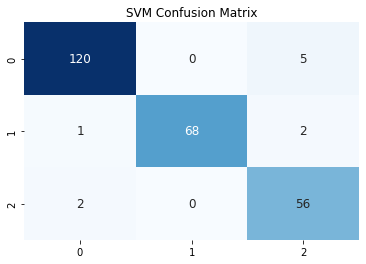

```python
from sklearn.metrics import confusion_matrix
acc_svm_simple =SVM_model.predict(X_test)
svm_scaled = confusion_matrix(y_test, acc_svm_simple)
plt.title("SVM Confusion Matrix")
sns.heatmap(svm_scaled, annot = True, cmap = "Blues", fmt = 'd', cbar = False, annot_kws = {"size": 12})
```

SO basic SVM model with scaled data is taking on all the attributes and giving the testing accuracy of 96%

### Part 2.3 c - Apply PCA on the data with 10 components.

```python
#step-1 Scale the data has been done - X_Saled
#step-2 Find the cov_matrix of X_scaled data
cov_mat = np.cov(X_scaled, rowvar = False)
print(cov_mat)
```

```
[[ 1.00118343  0.68569786  0.79086299  0.69055952  0.09164265  0.14842463
   0.81358214 -0.78968322  0.81465658  0.67694334  0.76297234  0.81497566
   0.58593517 -0.24988794  0.23635777  0.15720044  0.29889034  0.36598446]
 [ 0.68569786  1.00118343  0.79325751  0.6216467   0.15396023  0.25176438
   0.8489411  -0.82244387  0.84439802  0.96245572  0.79724837  0.83693508
   0.92691166  0.05200785  0.14436828 -0.01145212 -0.10455005  0.04640562]
 [ 0.79086299  0.79325751  1.00118343  0.76794246  0.15864319  0.26499957
   0.90614687 -0.9123854   0.89408198  0.77544391  0.86253904  0.88706577
   0.70660663 -0.22621115  0.1140589   0.26586088  0.14627113  0.33312625]
 [ 0.69055952  0.6216467   0.76794246  1.00118343  0.66423242  0.45058426
   0.73529816 -0.79041561  0.70922371  0.56962256  0.79435372  0.71928618
   0.53700678 -0.18061084  0.04877032  0.17394649  0.38266622  0.47186659]
 [ 0.09164265  0.15396023  0.15864319  0.66423242  1.00118343  0.64949139
   0.10385472 -0.18325156  0.07969786  0.1270594   0.27323306  0.08929427
   0.12211524  0.15313091 -0.05843967 -0.0320139   0.24016968  0.26804208]
 [ 0.14842463  0.25176438  0.26499957  0.45058426  0.64949139  1.00118343
   0.16638787 -0.18035326  0.16169312  0.30630475  0.31933428  0.1434227
   0.18996732  0.29608463  0.01561769  0.04347324 -0.02611148  0.14408905]
 [ 0.81358214  0.8489411   0.90614687  0.73529816  0.10385472  0.16638787
   1.00118343 -0.97275069  0.99092181  0.81004084  0.94978498  0.9941867
   0.80082111 -0.02757446  0.07454578  0.21267959  0.00563439  0.1189581 ]
 [-0.78968322 -0.82244387 -0.9123854  -0.79041561 -0.18325156 -0.18035326
  -0.97275069  1.00118343 -0.95011894 -0.77677186 -0.93748998 -0.95494487
  -0.76722075  0.10342428 -0.05266193 -0.18527244 -0.11526213 -0.2171615 ]
 [ 0.81465658  0.84439802  0.89408198  0.70922371  0.07969786  0.16169312
   0.99092181 -0.95011894  1.00118343  0.81189327  0.93533261  0.98938264
   0.79763248 -0.01551372  0.08386628  0.21495454 -0.01867064  0.09940372]
 [ 0.67694334  0.96245572  0.77544391  0.56962256  0.1270594   0.30630475
   0.81004084 -0.77677186  0.81189327  1.00118343  0.74586628  0.79555492
   0.86747579  0.04167099  0.13601231  0.00136727 -0.10407076  0.07686047]
 [ 0.76297234  0.79724837  0.86253904  0.79435372  0.27323306  0.31933428
   0.94978498 -0.93748998  0.93533261  0.74586628  1.00118343  0.94679667
   0.77983844  0.11321163  0.03677248  0.19446837  0.01423606  0.08579656]
 [ 0.81497566  0.83693508  0.88706577  0.71928618  0.08929427  0.1434227
   0.9941867  -0.95494487  0.98938264  0.79555492  0.94679667  1.00118343
   0.79595778 -0.01541878  0.07696823  0.20104818  0.00622636  0.10305714]
 [ 0.58593517  0.92691166  0.70660663  0.53700678  0.12211524  0.18996732
   0.80082111 -0.76722075  0.79763248  0.86747579  0.77983844  0.79595778
   1.00118343  0.19169941  0.16667971 -0.05621953 -0.22471583 -0.11814142]
 [-0.24988794  0.05200785 -0.22621115 -0.18061084  0.15313091  0.29608463
  -0.02757446  0.10342428 -0.01551372  0.04167099  0.11321163 -0.01541878
   0.19169941  1.00118343 -0.08846001 -0.12633227 -0.749751   -0.80307227]
 [ 0.23635777  0.14436828  0.1140589   0.04877032 -0.05843967  0.01561769
   0.07454578 -0.05266193  0.08386628  0.13601231  0.03677248  0.07696823
   0.16667971 -0.08846001  1.00118343 -0.03503155  0.1154338   0.09724079]
 [ 0.15720044 -0.01145212  0.26586088  0.17394649 -0.0320139   0.04347324
   0.21267959 -0.18527244  0.21495454  0.00136727  0.19446837  0.20104818
  -0.05621953 -0.12633227 -0.03503155  1.00118343  0.07740174  0.20523257]
 [ 0.29889034 -0.10455005  0.14627113  0.38266622  0.24016968 -0.02611148
   0.00563439 -0.11526213 -0.01867064 -0.10407076  0.01423606  0.00622636
  -0.22471583 -0.749751    0.1154338   0.07740174  1.00118343  0.89363767]
 [ 0.36598446  0.04640562  0.33312625  0.47186659  0.26804208  0.14408905
   0.1189581  -0.2171615   0.09940372  0.07686047  0.08579656  0.10305714
  -0.11814142 -0.80307227  0.09724079  0.20523257  0.89363767  1.00118343]]
```

```python
from sklearn.decomposition import PCA
#Calling 10 components
pca = PCA(n_components = 10,random_state = 10)
#fitting the model
pca.fit(X_scaled)
```

```
PCA(n_components=10, random_state=10)
```

```python
#Eigen values
print(pca.explained_variance_)
```

```
[9.40460261 3.01492206 1.90352502 1.17993747 0.91726063 0.53999263
 0.35887012 0.22193246 0.1606086  0.09185722]
```

```python
#Eigen vectors
print(pca.components_)
```

```
[[ 2.75283688e-01  2.93258469e-01  3.04609128e-01  2.67606877e-01
   8.05039890e-02  9.72756855e-02  3.17092750e-01 -3.14133155e-01
   3.13959064e-01  2.82830900e-01  3.09280359e-01  3.13788457e-01
   2.72047492e-01 -2.08137692e-02  4.14555082e-02  5.82250207e-02
   3.02795063e-02  7.41453913e-02]
 [-1.26953763e-01  1.25576727e-01 -7.29516436e-02 -1.89634378e-01
  -1.22174860e-01  1.07482875e-02  4.81181371e-02  1.27498515e-02
   5.99352482e-02  1.16220532e-01  6.22806229e-02  5.37843596e-02
   2.09233172e-01  4.88525148e-01 -5.50899716e-02 -1.24085090e-01
  -5.40914775e-01 -5.40354258e-01]
 [-1.19922479e-01 -2.48205467e-02 -5.60143254e-02  2.75074211e-01
   6.42012966e-01  5.91801304e-01 -9.76283108e-02  5.76484384e-02
  -1.09512416e-01 -1.70641987e-02  5.63239801e-02 -1.08840729e-01
  -3.14636493e-02  2.86277015e-01 -1.15679354e-01 -7.52828901e-02
   8.73592034e-03  3.95242743e-02]
 [ 7.83843562e-02  1.87337408e-01 -7.12008427e-02 -4.26053415e-02
   3.27257119e-02  3.14147277e-02 -9.57485748e-02  8.22901952e-02
  -9.24582989e-02  1.88005612e-01 -1.19844008e-01 -9.17449325e-02
   2.00095228e-01 -6.55051354e-02  6.04794251e-01 -6.66114117e-01
   1.05526253e-01  4.74890311e-02]
 [ 6.95178336e-02 -8.50649539e-02  4.06645651e-02 -4.61473714e-02
  -4.05494487e-02  2.13432566e-01 -1.54853055e-02  7.68518712e-02
   2.17633157e-03 -6.06366845e-02 -4.56472367e-04 -1.95548315e-02
  -6.15991681e-02  1.45530146e-01  7.29189842e-01  5.99196401e-01
  -1.00602332e-01 -2.98614819e-02]
 [ 1.44875476e-01 -3.02731148e-01 -1.38405773e-01  2.48136636e-01
   2.36932611e-01 -4.19330747e-01  1.16100153e-01 -1.41840112e-01
   9.80561329e-02 -4.61674972e-01  2.36225434e-01  1.57820194e-01
  -1.35576278e-01  2.41356821e-01  2.03209257e-01 -1.91960802e-01
   1.56939174e-01 -2.41222817e-01]
 [ 4.51862331e-01 -2.49103387e-01  7.40350569e-02 -1.76912814e-01
  -3.97876601e-01  5.03413610e-01  6.49879382e-02  1.38112945e-02
   9.66573058e-02 -1.04552173e-01  1.14622578e-01  8.37350220e-02
  -3.73944382e-01  1.11952983e-01 -8.06328902e-02 -2.84558723e-01
   1.81451818e-02  1.57237839e-02]
 [-5.66136785e-01 -1.79851809e-01  4.34748988e-01  1.01998360e-01
  -6.87147927e-02  1.61153097e-01  1.00688056e-01 -2.15497166e-01
   6.35933915e-02 -2.49495867e-01  5.02096319e-02  4.37649907e-02
  -1.08474496e-01 -3.40878491e-01  1.56487670e-01 -2.08774083e-01
  -3.04580219e-01 -3.04186304e-02]
 [-4.84418105e-01 -1.41569001e-02 -1.67572478e-01 -2.30313563e-01
  -2.77128307e-01  1.48032250e-01  5.44574214e-02 -1.56867362e-01
   5.24978759e-03 -6.10362445e-02  2.97588112e-01  8.33669838e-02
   2.41655483e-01  3.20221887e-01  2.21054148e-02  1.01761758e-02
   5.17222779e-01  1.71506343e-01]
 [-2.60076393e-01  9.80779086e-02 -2.05031597e-01 -4.77888949e-02
   1.08075009e-01 -1.18266345e-01  1.65167200e-01 -1.51612333e-01
   1.93777917e-01  4.69059999e-01 -1.29986011e-01  1.58203940e-01
  -6.86493700e-01  1.27648385e-01  9.83643219e-02 -3.55150608e-02
   1.93956186e-02  6.41314778e-02]]
```

### Part 2.3 d - Visualize Cumulative Variance Explained with Number of Components.

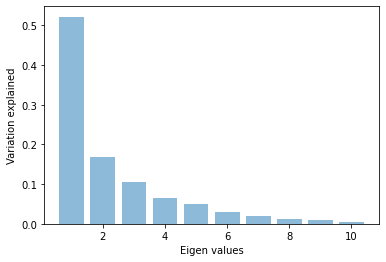

```python
#Plot Eigen values
plt.bar(list(range(1,11)), pca.explained_variance_ratio_, alpha = 0.5, align = 'center')
plt.ylabel('Variation explained')
plt.xlabel('Eigen values')
plt.show()
```

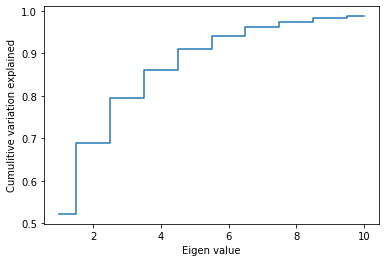

```python
#Plot for cumulitive variation

plt.step(list(range(1,11)), np.cumsum(pca.explained_variance_ratio_), where = 'mid')
plt.ylabel('Cumulitive variation explained')
plt.xlabel('Eigen value')
plt.show()
```

### Part 2.3 e - Draw a horizontal line on the above plot to highlight the threshold of 90%.

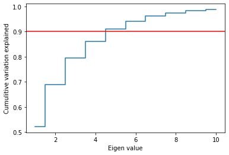

```python
plt.step(list(range(1,11)), np.cumsum(pca.explained_variance_ratio_), where = 'mid')
threshold = 0.9
plt.ylabel('Cumulitive variation explained')
plt.xlabel('Eigen value')
plt.axhline(y=threshold, color='r', linestyle='-')
plt.show()
```

### Part 2.3 f - Apply PCA on the data. This time Select Minimum Components with 90% or above variance explained.

```python
#from above plot the minimum components with 90% variance is n=5
pca_5 = PCA(n_components = 5,random_state = 10)
pca_5.fit(X_scaled)
print(pca_5.components_)
print(pca_5.explained_variance_ratio_)
```

```
[[ 2.75283688e-01  2.93258469e-01  3.04609128e-01  2.67606877e-01
   8.05039890e-02  9.72756855e-02  3.17092750e-01 -3.14133155e-01
   3.13959064e-01  2.82830900e-01  3.09280359e-01  3.13788457e-01
   2.72047492e-01 -2.08137692e-02  4.14555082e-02  5.82250207e-02
   3.02795063e-02  7.41453913e-02]
 [-1.26953763e-01  1.25576727e-01 -7.29516436e-02 -1.89634378e-01
  -1.22174860e-01  1.07482875e-02  4.81181371e-02  1.27498515e-02
   5.99352482e-02  1.16220532e-01  6.22806229e-02  5.37843596e-02
   2.09233172e-01  4.88525148e-01 -5.50899716e-02 -1.24085090e-01
  -5.40914775e-01 -5.40354258e-01]
 [-1.19922479e-01 -2.48205467e-02 -5.60143254e-02  2.75074211e-01
   6.42012966e-01  5.91801304e-01 -9.76283108e-02  5.76484384e-02
  -1.09512416e-01 -1.70641987e-02  5.63239801e-02 -1.08840729e-01
  -3.14636493e-02  2.86277015e-01 -1.15679354e-01 -7.52828901e-02
   8.73592034e-03  3.95242743e-02]
 [ 7.83843561e-02  1.87337407e-01 -7.12008427e-02 -4.26053409e-02
   3.27257116e-02  3.14147277e-02 -9.57485748e-02  8.22901953e-02
  -9.24582989e-02  1.88005612e-01 -1.19844008e-01 -9.17449327e-02
   2.00095228e-01 -6.55051353e-02  6.04794251e-01 -6.66114117e-01
   1.05526254e-01  4.74890311e-02]
 [ 6.95178336e-02 -8.50649539e-02  4.06645651e-02 -4.61473714e-02
  -4.05494487e-02  2.13432566e-01 -1.54853055e-02  7.68518712e-02
   2.17633167e-03 -6.06366846e-02 -4.56472321e-04 -1.95548316e-02
  -6.15991682e-02  1.45530146e-01  7.29189842e-01  5.99196401e-01
  -1.00602332e-01 -2.98614819e-02]]
[0.52186034 0.16729768 0.10562639 0.0654746  0.05089869]
```

### Part 2.3 g - Train SVM model on components selected from above step.

```python
#Transforming the scaled data into 5 dimensions
X_scaled5= pca_5.transform(X_scaled)
```

```python
X_scaled5.shape
```

```
(846, 5)
```

```python
#using train- test split function with 70:30 ratio
X_train, X_test, y_train, y_test = train_test_split(X_scaled5,y, test_size = 0.30, random_state = 10)

#defining model
accuracies = {}
SVM_model = SVC()

#fitting the model
SVM_model.fit(X_train, y_train)
y_pred = SVM_model.predict(X_test)
acc_svm = SVM_model.score(X_test, y_test) *100

#printing accuracies
accuracies['SVMPCA'] = acc_svm
print(SVM_model.score(X_train, y_train))
print(SVM_model.score(X_test, y_test))
```

```
0.7922297297297297
0.7834645669291339
```

### Part 2.3 h - Print Classification metrics for train data of above model and share insights.

```python
print(classification_report(y_test,y_pred))
```

```
              precision    recall  f1-score   support

           0       0.82      0.90      0.86       125
           1       0.87      0.63      0.73        71
           2       0.64      0.72      0.68        58

    accuracy                           0.78       254
   macro avg       0.78      0.75      0.76       254
weighted avg       0.79      0.78      0.78       254
```

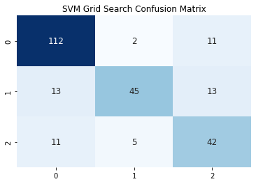

```python
acc_svm = SVM_model.predict(X_test)
cm_pca5 = confusion_matrix(y_test, acc_svm)
plt.title("SVM Grid Search Confusion Matrix")
sns.heatmap(cm_pca5, annot = True, cmap = "Blues", fmt = 'd', cbar = False, annot_kws = {"size": 12})
```

With 5 components we have reduced the overfitting of model and reduced the dimensions too . Yes accuracy is dropped but so is the features.

# 2.4. Performance Improvement:

### Part 2.4 a - Train another SVM on the components out of PCA. Tune the parameters to improve performance.

```python
#Finding best parameters for our SVM model
#importing modules
from sklearn.model_selection import GridSearchCV
from sklearn import svm
#Finding best parameters for our SVM model

param = {
    'C' : [0.01,0.05,0.5,1],
    'kernel' :['linear','rbf']
}

grid_svm = GridSearchCV(SVM_model, param_grid = param, scoring = 'accuracy', cv = 10)
grid_svm.fit(X_train,y_train)
```

```
GridSearchCV(cv=10, estimator=SVC(),
             param_grid={'C': [0.01, 0.05, 0.5, 1],
                         'kernel': ['linear', 'rbf']},
             scoring='accuracy')
```

### Part 2.4 b- Share best Parameters observed from above step.

```python
#The best hyper parameters set
print("Best Hyper Parameters:\n",grid_svm.best_params_)
```

```
Best Hyper Parameters:
 {'C': 1, 'kernel': 'rbf'}
```

```python
# Cross Validation related
#Kernel = rbf, C = 1
model_svm = SVC(C = 1, kernel = 'rbf', gamma = 1)
X_train, X_test, y_train, y_test = train_test_split(X_scaled5, y, test_size = 0.30, random_state = 10)
model_svm.fit(X_train, y_train)
y_pred = model_svm.predict(X_test)

acc_svm_gs = model_svm.score(X_test, y_test) * 100
accuracies['SVM_GS'] = acc_svm_gs
print(model_svm.score(X_test, y_test))
```

```
0.8031496062992126
```

### Part 2.4 c- Print Classification metrics for train data of above model and share relative improvement in performance in all the models along with insights.

```python
print(classification_report(y_test,y_pred))
```

```
              precision    recall  f1-score   support

           0       0.82      0.90      0.85       125
           1       0.92      0.68      0.78        71
           2       0.68      0.76      0.72        58

    accuracy                           0.80       254
   macro avg       0.81      0.78      0.78       254
weighted avg       0.81      0.80      0.80       254
```

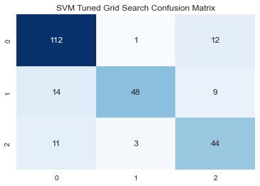

```python
acc_svm_gs = model_svm.predict(X_test)
cm_svm_gs = confusion_matrix(y_test, acc_svm_gs)
plt.title("SVM Tuned Grid Search Confusion Matrix")
sns.heatmap(cm_svm_gs, annot = True, cmap = "Blues", fmt = 'd', cbar = False, annot_kws = {"size": 12})
```

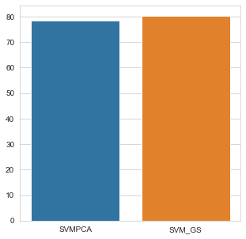

```python
sns.set_style('whitegrid')
plt.figure(figsize = (5,5))
plt.yticks(np.arange(0,100,10))
sns.barplot(x = list(accuracies.keys()), y = list(accuracies.values()))
```

#### As seen SVM base model gives 96% accuracy in testing data but it has considered every Features/Dimensions inside the model. Than we tried to reduce the dimensions by finding the best value of PCA, n_components=5 which gave the accuracy of 78%. Accuracy is dropped but so are the dimensions. So we know that accuracy is not always the best measure for models performance. Here we have reduced the dimension to 5 components which will reduce the computational time and cost. Now after achieving 78% accuracy we tried to tune the models performance by selecting best parameters and now the accuracy has reached to 80.3% with 5 n_components.

# 2.5. Data Understanding & Cleaning:

### Part 2.5 a - Explain pre-requisite/assumptions of PCA.

• There must be linearity in the data set, i.e. the variables combine in a linear manner to form the dataset. The variables exhibit relationships among themselves.

• PCA assumes that the principal component with high variance must be paid attention and the PCs with lower variance are disregarded as noise. Pearson correlation coefficient framework led to the origin of PCA, and there it was assumed first that the axes with high variance would only be turned into principal components.

• All variables should be accessed on the same ratio level of measurement. The most preferred norm is at least 150 observations of the sample set with a ratio measurement of 5:1.

• Extreme values that deviate from other data points in any dataset, which are also called outliers, should be less. More number of outliers will represent experimental errors and will degrade your ML model/algorithm.

• The feature set must be correlated and the reduced feature set after applying PCA will represent the original data set but in an effective way with fewer dimensions.

### Part 2.5 b - Explain advantages and limitations of PCA.

Advantages of PCA

Principal component analysis (PCA) is a statistical method used to transform a large number of possibly correlated variables into a much smaller number of uncorrelated variables referred to as principal components. PCA can be used as a data reduction technique as it allows us to find the most important variables that are needed to describe a dataset. PCA can also be used to reduce the dimensionality of the data space in order to get insight on the inner structure of the data. This is helpful when dealing with large datasets.

It helps to improve the performance of algorithm. Improve Data visualization. Remove co-related attributes and reduce the overfitting

Limitation of PCA

PCA is a great tool to analyze your data and extract two or three most important factors. It is great to spot the outliers and the trend. But, it has some limitations like: It is not suitable for small data sets (Generally, data set should have more than 30 rows). It does not find the important factors but selects them based on the values. So, it is difficult to find the important factors. It does not have a strong mathematical structure behind it. It is difficult to compare the data with PCA. It cannot find any non-linear relationships.

Also in PCA for feature elimination, The disadvantage is that we would gain no insight from the dropped variables and loose any information they contain Sometimes its had to interpret the data(Independent variables) that processed out from the analysis.